# Movie Ratings Group Project

Group 5

2022-10-27

## Summary of DataSet -

Two datasets, one with 10,329 movies and their genres, and another with 105,339 IMDB ratings (scale of 5) across 668 Users (selected randomly) between March 1996 and September 2018.

### Initial dataset manipulation

Movie Ratings Dataset Join test

```r
getwd()
```

```
## [1] "C:/Users/Aditya Kumar/Documents/GitHub/DATS6101_Group5_Project1/R Codes/IMDB_Movie_Dataset"
```

```r
movies <- data.frame(read.csv("movies.csv"))
ratings <- data.frame(read.csv("ratings.csv"))
movie_ratings <- merge(x = movies, y = ratings, by = 'movieId', all.y = TRUE)

# Null checks
max(is.na(movie_ratings))
```

```
## [1] 0
```

```r
# Splitting the Genres into unique rows
# install.packages('magrittr') - for pipe operator
# install.packages('tidyverse') - to create unique rows
library(magrittr)
library(tidyverse)
movie_ratings <- movie_ratings %>% separate_rows(genres)
movies <- movies %>% separate_rows(genres)
unique(movies$genres)
```

```
##  [1] "Adventure"   "Animation"   "Children"    "Comedy"      "Fantasy"
##  [6] "Romance"     "Drama"       "Action"      "Crime"       "Thriller"
## [11] "Horror"      "Mystery"     "Sci"         "Fi"          "IMAX"
## [16] "War"         "Musical"     "Documentary" "Western"     "Film"
## [21] "Noir"        ""            "no"          "genres"      "listed"
```

### Actual Start to Project

Importing Data

```r
rm(list=ls())
library(tidyverse)

movies <- read_csv("movies.csv")
ratings <- read_csv("ratings.csv")

str(movies)
```

```
## spec_tbl_df [10,329 × 3] (S3: spec_tbl_df/tbl_df/tbl/data.frame)
##  $ movieId: num [1:10329] 1 2 3 4 5 6 7 8 9 10 ...
##  $ title  : chr [1:10329] "Toy Story (1995)" "Jumanji (1995)" "Grumpier Old Men (1995)" "Waiting to Exhale (1995)" ...
##  $ genres : chr [1:10329] "Adventure|Animation|Children|Comedy|Fantasy" "Adventure|Children|Fantasy" "Comedy|Romance" "Comedy|Drama|Romance" ...
##  - attr(*, "spec")=
##   .. cols(
##   ..   movieId = col_double(),
##   ..   title = col_character(),
##   ..   genres = col_character()
##   .. )
##  - attr(*, "problems")=<externalptr>
```

```r
str(ratings)
```

```
## spec_tbl_df [105,339 × 4] (S3: spec_tbl_df/tbl_df/tbl/data.frame)
##  $ userId   : num [1:105339] 1 1 1 1 1 1 1 1 1 1 ...
##  $ movieId  : num [1:105339] 16 24 32 47 50 110 150 161 165 204 ...
##  $ rating   : num [1:105339] 4 1.5 4 4 4 4 3 4 3 0.5 ...
##  $ timestamp: num [1:105339] 1.22e+09 1.22e+09 1.22e+09 1.22e+09 1.22e+09 ...
##  - attr(*, "spec")=
##   .. cols(
##   ..   userId = col_double(),
##   ..   movieId = col_double(),
##   ..   rating = col_double(),
##   ..   timestamp = col_double()
##   .. )
##  - attr(*, "problems")=<externalptr>
```

Null Checks:

```r
max(is.na(movies))
```

```
## [1] 0
```

```r
max(is.na(ratings))
```

```
## [1] 0
```

## Data Preprocessing

Expanding Movies Dataset

```r
library(data.table)
movies <- data.table(movies)
dummy_movie_genre_expanded <- movies[, list(title,genres = unlist(strsplit(genres, split = "|", fixed = T))), by = movieId]

# remove spaces
dummy_movie_genre_expanded$genres <- str_trim(dummy_movie_genre_expanded$genres)
str(dummy_movie_genre_expanded)
```

```
## Classes 'data.table' and 'data.frame':   23114 obs. of  3 variables:
##  $ movieId: num  1 1 1 1 1 2 2 2 3 3 ...
##  $ title  : chr  "Toy Story (1995)" "Toy Story (1995)" "Toy Story (1995)" "Toy Story (1995)" ...
##  $ genres : chr  "Adventure" "Animation" "Children" "Comedy" ...
##  - attr(*, ".internal.selfref")=<externalptr>
```

Checking Movies with only one genre listed

```r
movie_count_one <- movie_genre_expanded %>%
  group_by(movieId) %>%
  summarize(
    count = n()
  ) %>%
  filter(count == 1)
movie_count_one
```

Joining Datasets

```r
#movies_drop <- movies %>% select(-3)
#movies_join <- left_join(movie_genre_expanded, movies_drop, by = "movieId")
movie_ratings_expanded <- full_join(dummy_movie_genre_expanded, ratings, by = "movieId")
```

Subsetting Movies with one genre

```r
one_genre <- inner_join(movies_join, movie_count_one)
one_genre
```

Finding proportion of genres

```r
one_genre_prop <- one_genre %>%
  group_by(genres) %>%
  summarize(
    count = n(),
    prop = n() / 3041
  )

one_genre_prop <- one_genre_prop[order(one_genre_prop$prop, decreasing = T),]
one_genre_prop
```

```r
all_movies_prop <- movies_join %>%
  group_by(genres) %>%
  summarize(
    count = n(),
    prop = n() / 10329
  )

all_movies_prop <- all_movies_prop[order(all_movies_prop$prop, decreasing = T),]
all_movies_prop
```

```r
prop_join <- full_join(one_genre_prop, all_movies_prop, by = "genres")
prop_join <- rename(prop_join,
       count_one = count.x,
       prop_one = prop.x,
       count_all = count.y,
       prop_all = prop.y)
prop_join[is.na(prop_join)] = 0
prop_join
```

Doing a Chi-squared Goodness of fit test to see if proportions of one genre are different from all of the genres

```r
# chisq.test(prop_join$count_one, p = prop_join$prop_all)
```

Chi-squared test does not work because the proportion of genres does not equal 1 in the population dataset. We’ll have to think of another way to see if these two stats are significantly different.

Checking Dataset integrity and number of genres.

```r
unique(movie_ratings_expanded$genres)
```

```
##  [1] "Adventure"          "Animation"          "Children"
##  [4] "Comedy"             "Fantasy"            "Romance"
##  [7] "Drama"              "Action"             "Crime"
## [10] "Thriller"           "Horror"             "Mystery"
## [13] "Sci-Fi"             "IMAX"               "War"
## [16] "Musical"            "Documentary"        "Western"
## [19] "Film-Noir"          "(no genres listed)"
```

```r
sum(is.na(movie_ratings_expanded$genres))
```

```
## [1] 0
```

20 different genres

Some issues with the final dataset:

- There are multiple genres per movie and multiple reviews per movie. This means the review ratings are duplicated in the final dataset in movies with multiple genres after they have been expanded. We might want to join the datasets with all genres listed in one column instead.
- Overlap of genres between different movies might cause some issues.
- The dataset is very long. We might want to subset it to those movies with just one genre (which would address the issue above), or perhaps narrow it down to a certain time frame.
- The timestamp variable is being interpreted as numeric. We will need to figure out how to fix this.

*Extract year from movie titles*

Columns to make:  
* Average user ratings per movie  
* Number of User ratings per movie  
* Year movie is made

```r
genre_list <- list(unique(movies_join$genres))
for (g in genre_list) {
  movie_wide <- movies %>%
    mutate(
      g = if_else(grepl(g, movies$genres), 1, 0)
    )
}

str(movie_wide)
unique(movies_join$genres)
```

Creating New Variables - To perform 2 sample t-tests for comparing each Genre, with the rest of the Genre.

```r
dummy_movie_wide <- movies %>%
  mutate(
    Adventure = if_else(grepl("Adventure", movies$genres), 1, 0),
    Animation = if_else(grepl("Animation", movies$genres), 1, 0),
    Children = if_else(grepl("Children", movies$genres), 1, 0),
    Comedy = if_else(grepl("Comedy", movies$genres), 1, 0),
    Fantasy = if_else(grepl("Fantasy", movies$genres), 1, 0),
    Romance = if_else(grepl("Romance", movies$genres), 1, 0),
    Drama = if_else(grepl("Drama", movies$genres), 1, 0),
    Action = if_else(grepl("Action", movies$genres), 1, 0),
    Crime = if_else(grepl("Crime", movies$genres), 1, 0),
    Thriller = if_else(grepl("Thriller", movies$genres), 1, 0),
    Horror = if_else(grepl("Horror", movies$genres), 1, 0),
    Mystery = if_else(grepl("Mystery", movies$genres), 1, 0),
    `Sci-Fi` = if_else(grepl("Sci-Fi", movies$genres), 1, 0),
    IMAX = if_else(grepl("IMAX", movies$genres), 1, 0),
    War = if_else(grepl("War", movies$genres), 1, 0),
    Musical = if_else(grepl("Musical", movies$genres), 1, 0),
    Documentary = if_else(grepl("Documentary", movies$genres), 1, 0),
    Western = if_else(grepl("Western", movies$genres), 1, 0),
    `Film-Noir` = if_else(grepl("Film-Noir", movies$genres), 1, 0),
    No_genre_listed = if_else(grepl("(no genres listed)", movies$genres), 1, 0)
  )
str(dummy_movie_wide)
```

```
## Classes 'data.table' and 'data.frame':   10329 obs. of  23 variables:
##  $ movieId        : num  1 2 3 4 5 6 7 8 9 10 ...
##  $ title          : chr  "Toy Story (1995)" "Jumanji (1995)" "Grumpier Old Men (1995)" "Waiting to Exhale (1995)" ...
##  $ genres         : chr  "Adventure|Animation|Children|Comedy|Fantasy" "Adventure|Children|Fantasy" "Comedy|Romance" "Comedy|Drama|Romance" ...
##  $ Adventure      : num  1 1 0 0 0 0 0 1 0 1 ...
##  $ Animation      : num  1 0 0 0 0 0 0 0 0 0 ...
##  $ Children       : num  1 1 0 0 0 0 0 1 0 0 ...
##  $ Comedy         : num  1 0 1 1 1 0 1 0 0 0 ...
##  $ Fantasy        : num  1 1 0 0 0 0 0 0 0 0 ...
##  $ Romance        : num  0 0 1 1 0 0 1 0 0 0 ...
##  $ Drama          : num  0 0 0 1 0 0 0 0 0 0 ...
##  $ Action         : num  0 0 0 0 0 1 0 0 1 1 ...
##  $ Crime          : num  0 0 0 0 0 1 0 0 0 0 ...
##  $ Thriller       : num  0 0 0 0 0 1 0 0 0 1 ...
##  $ Horror         : num  0 0 0 0 0 0 0 0 0 0 ...
##  $ Mystery        : num  0 0 0 0 0 0 0 0 0 0 ...
##  $ Sci-Fi         : num  0 0 0 0 0 0 0 0 0 0 ...
##  $ IMAX           : num  0 0 0 0 0 0 0 0 0 0 ...
##  $ War            : num  0 0 0 0 0 0 0 0 0 0 ...
##  $ Musical        : num  0 0 0 0 0 0 0 0 0 0 ...
##  $ Documentary    : num  0 0 0 0 0 0 0 0 0 0 ...
##  $ Western        : num  0 0 0 0 0 0 0 0 0 0 ...
##  $ Film-Noir      : num  0 0 0 0 0 0 0 0 0 0 ...
##  $ No_genre_listed: num  0 0 0 0 0 0 0 0 0 0 ...
##  - attr(*, ".internal.selfref")=<externalptr>
```

```r
#Code chunk for testing proportions
sapply(dummy_movie_wide, mean)
```

```r
dummy_rating_mean <- ratings %>%
  group_by(movieId) %>%
  summarize(
    mean_rating = mean(rating)
  )

movies_mean_rating <- left_join(dummy_movie_wide,dummy_rating_mean, by = 'movieId')
movie_genre_expanded_mean <- left_join(dummy_movie_genre_expanded,dummy_rating_mean,by ='movieId')
movies_mean_rating
```

```
##        movieId                               title
##     1:       1                    Toy Story (1995)
##     2:       2                      Jumanji (1995)
##     3:       3             Grumpier Old Men (1995)
##     4:       4            Waiting to Exhale (1995)
##     5:       5  Father of the Bride Part II (1995)
##    ---
## 10325:  146684       Cosmic Scrat-tastrophe (2015)
## 10326:  146878          Le Grand Restaurant (1966)
## 10327:  148238      A Very Murray Christmas (2015)
## 10328:  148626                The Big Short (2015)
## 10329:  149532 Marco Polo: One Hundred Eyes (2015)
##                                             genres Adventure Animation Children
##     1: Adventure|Animation|Children|Comedy|Fantasy         1         1        1
##     2:                  Adventure|Children|Fantasy         1         0        1
```

[output cut: 45 more lines]

```r
movie_genre_expanded_mean
```

```
##        movieId                               title             genres
##     1:       1                    Toy Story (1995)          Adventure
##     2:       1                    Toy Story (1995)          Animation
##     3:       1                    Toy Story (1995)           Children
##     4:       1                    Toy Story (1995)             Comedy
##     5:       1                    Toy Story (1995)            Fantasy
##    ---
## 23110:  146684       Cosmic Scrat-tastrophe (2015)             Comedy
## 23111:  146878          Le Grand Restaurant (1966)             Comedy
## 23112:  148238      A Very Murray Christmas (2015)             Comedy
## 23113:  148626                The Big Short (2015)              Drama
## 23114:  149532 Marco Polo: One Hundred Eyes (2015) (no genres listed)
##        mean_rating
##     1:    3.907328
##     2:    3.907328
##     3:    3.907328
##     4:    3.907328
##     5:    3.907328
##    ---
## 23110:    4.000000
## 23111:    2.500000
## 23112:    3.000000
## 23113:    4.333333
## 23114:    4.000000
```

Expanding with Movie Ratings

```r
library(data.table)
#movies_mean_rating <- data.table(movies_mean_rating)
#movies_mean_rating_expanded <- movies_mean_rating[ , list(title,genres = unlist(strsplit(genres, split = "|", fixed = T))), by = movieId]

# remove spaces
#movies_rating_expanded$genres <- str_trim(movies_rating_expanded$genres)

# rejoining tables
#movies_rating <- select(movies_rating, -genres)
#movies_rating_expanded <- full_join(movies_rating_expanded, movies_rating, by = 'movieId')
#str(movies_rating_expanded)
```

Creating Year Variable

```r
movie_ratings_expanded$year <- str_sub(movie_ratings_expanded$title, start = nchar(movie_ratings_expanded$title)-4, end = nchar(movie_ratings_expanded$title)-1) %>% str_trim()
movie_ratings_expanded$year <- as.factor(movie_ratings_expanded$year)

movies_mean_rating$year <- str_sub(movies_mean_rating$title, start = nchar(movies_mean_rating$title)-4, end = nchar(movies_mean_rating$title)-1) %>% str_trim()
movies_mean_rating$year <- as.factor(movies_mean_rating$year)

movie_genre_expanded_mean$year <- str_sub(movie_genre_expanded_mean$title, start = nchar(movie_genre_expanded_mean$title)-4, end = nchar(movie_genre_expanded_mean$title)-1) %>% str_trim()
movie_genre_expanded_mean$year <- as.factor(movie_genre_expanded_mean$year)

str(movie_genre_expanded_mean)
```

```
## Classes 'data.table' and 'data.frame':   23114 obs. of  5 variables:
##  $ movieId    : num  1 1 1 1 1 2 2 2 3 3 ...
##  $ title      : chr  "Toy Story (1995)" "Toy Story (1995)" "Toy Story (1995)" "Toy Story (1995)" ...
##  $ genres     : chr  "Adventure" "Animation" "Children" "Comedy" ...
##  $ mean_rating: num  3.91 3.91 3.91 3.91 3.91 ...
##  $ year       : Factor w/ 101 levels "","1902","1915",..: 81 81 81 81 81 81 81 81 81 81 ...
##  - attr(*, ".internal.selfref")=<externalptr>
```

## Data Visualization

Since each movie can belong to multiple Genres, the rating given to that movie is counted towards all the Genres the movie is applicable to.

```r
rating_by_genre <- movie_ratings_expanded %>%
  group_by(genres) %>%
  summarize(
    Count = n_distinct(userId),
    Mean = mean(rating, na.rm=T),
    SD = sd(rating, na.rm=T),
    Min = min(rating, na.rm=T),
    Max = max(rating, na.rm=T)
  )

rating_by_genre <- rating_by_genre[order(rating_by_genre$Mean, decreasing = TRUE),]
rating_by_genre
```

```
## # A tibble: 20 × 6
##    genres             Count  Mean    SD   Min   Max
##    <chr>              <int> <dbl> <dbl> <dbl> <dbl>
##  1 Film-Noir            288  3.91 0.884   0.5     5
##  2 War                  601  3.78 0.969   0.5     5
##  3 Mystery              621  3.65 0.994   0.5     5
##  4 Drama                669  3.65 0.985   0.5     5
##  5 Documentary          250  3.64 0.982   0.5     5
##  6 Crime                663  3.64 1.01    0.5     5
##  7 IMAX                 448  3.64 0.997   0.5     5
##  8 Animation            574  3.64 0.985   0.5     5
##  9 Musical              538  3.57 1.03    0.5     5
## 10 Western              469  3.57 0.991   0.5     5
## 11 Romance              663  3.54 1.02    0.5     5
## 12 Adventure            667  3.52 1.04    0.5     5
## 13 Fantasy              645  3.50 1.07    0.5     5
## 14 Thriller             666  3.50 1.03    0.5     5
## 15 Sci-Fi               660  3.45 1.09    0.5     5
## 16 Action               666  3.45 1.06    0.5     5
## 17 Children             614  3.44 1.05    0.5     5
## 18 Comedy               668  3.42 1.07    0.5     5
## 19 Horror               596  3.28 1.14    0.5     5
## 20 (no genres listed)     3  3.07 0.886   2       4
```

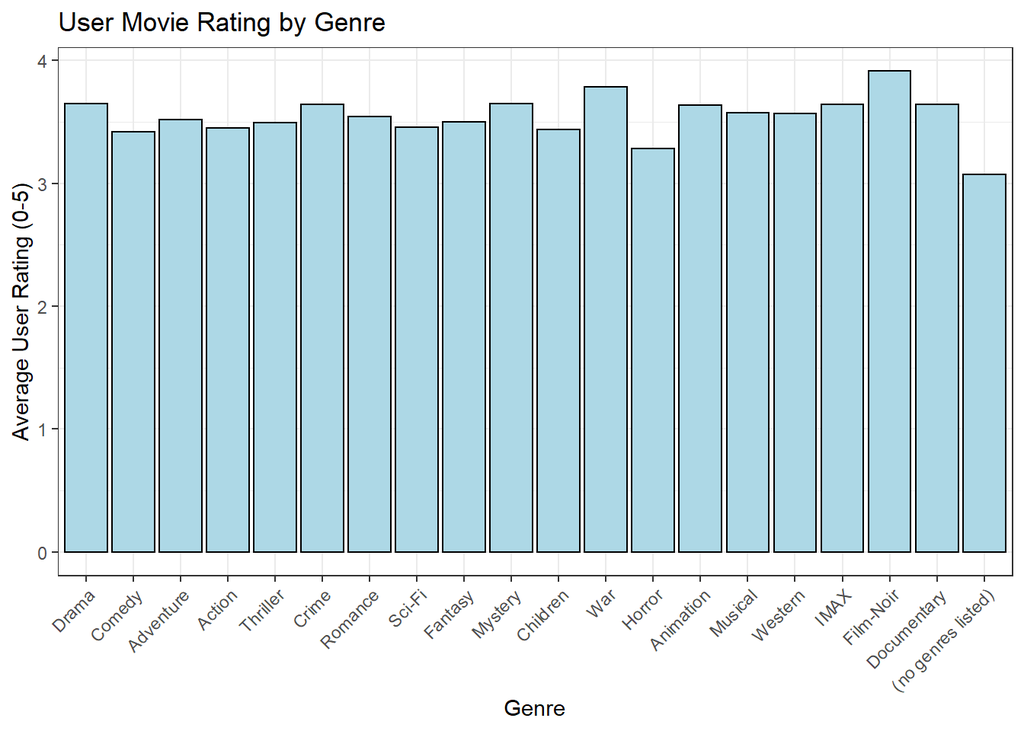

```r
rating_by_genre %>%
  ggplot(
    aes(
      x = fct_reorder(genres, Count, .desc = T),
      y = Mean
    )
  ) +
  geom_col(fill = "lightblue", color = "black") +
  labs(
    title = "User Movie Rating by Genre",
    x = "Genre",
    y = "Average User Rating (0-5)"
  ) +
  theme_bw() +
  theme(axis.text.x = element_text(angle = 45, hjust = 1))
```

However, the ratings given in each genre vary. Some genres can have a higher user contribution than others.

Calculating Rating by Year

```r
rating_by_year <- movie_ratings_expanded %>%
  group_by(year) %>%
  summarize(
    Count = n_distinct(userId),
    Mean = mean(rating, na.rm=T),
    SD = sd(rating, na.rm=T),
    Min = min(rating, na.rm=T),
    Max = max(rating, na.rm=T)
  )

rating_by_year <- rating_by_year[order(rating_by_year$year),]
rating_by_year
```

```
## # A tibble: 101 × 6
##    year   Count   Mean     SD   Min    Max
##    <fct>  <int>  <dbl>  <dbl> <dbl>  <dbl>
##  1 ""         2   2     0       2      2
##  2 "1902"     2   3.75  0.267   3.5    4
##  3 "1915"     3   2.17  1.37    0.5    3.5
##  4 "1916"     1 NaN    NA     Inf   -Inf
##  5 "1919"     2   3.25  0.289   3      3.5
##  6 "1920"    13   3.82  1.23    0.5    5
##  7 "1921"     7   3.59  1.38    1      5
##  8 "1922"    17   3.75  1.01    2      5
##  9 "1923"     5   3.68  1.10    2      5
## 10 "1924"     5   3.81  0.730   3      5
## # … with 91 more rows
```

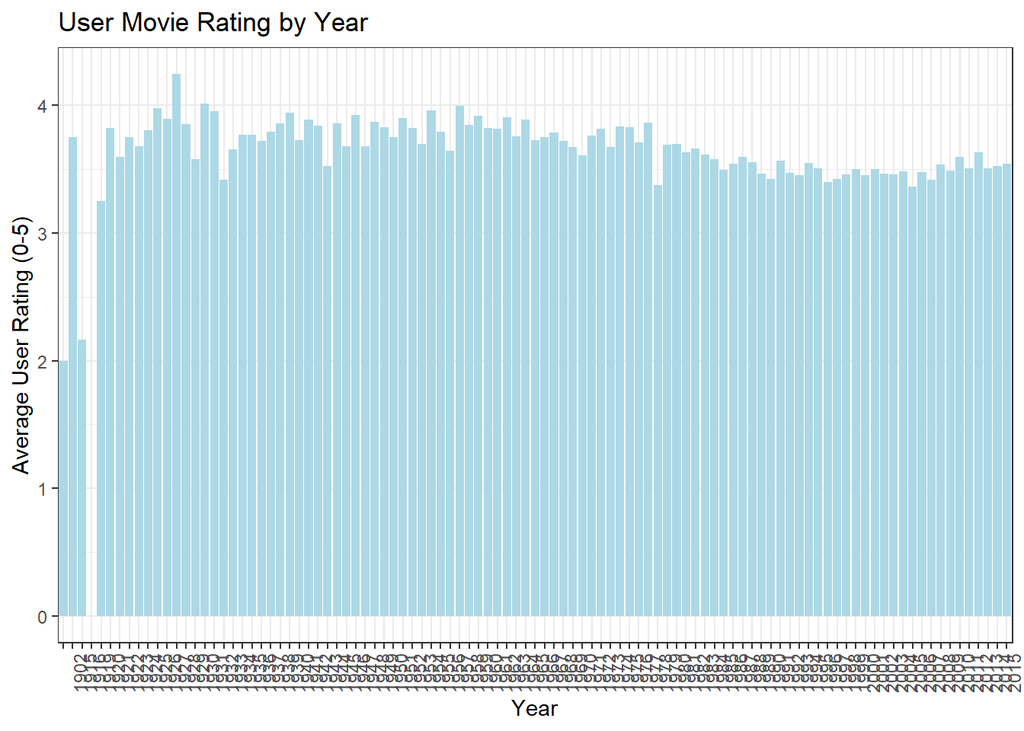

```r
rating_by_year %>%
  ggplot(
    aes(
      x = year,
      y = Mean
    )
  ) +
  geom_col(fill = "lightblue") +
   labs(
    title = "User Movie Rating by Year",
    x = "Year",
    y = "Average User Rating (0-5)"
  ) +
  theme_bw() +
  theme(axis.text.x = element_text(angle = 90))
```

## Statistical Testing

**Testing Adventure**

```r
Adventure <- movies_mean_rating %>% filter(Adventure == 1)
Not_adventure <- movies_mean_rating %>% filter(Adventure == 0)

t.test(Adventure$mean_rating)
```

```
##
##  One Sample t-test
##
## data:  Adventure$mean_rating
## t = 144.18, df = 1163, p-value < 2.2e-16
## alternative hypothesis: true mean is not equal to 0
## 95 percent confidence interval:
##  3.158024 3.245159
## sample estimates:
## mean of x
##  3.201591
```

```r
t.test(Adventure$mean_rating, Not_adventure$mean_rating)
```

```
##
##  Welch Two Sample t-test
##
## data:  Adventure$mean_rating and Not_adventure$mean_rating
## t = 1.1536, df = 1535.3, p-value = 0.2488
## alternative hypothesis: true difference in means is not equal to 0
## 95 percent confidence interval:
##  -0.01924326  0.07419970
## sample estimates:
## mean of x mean of y
##  3.201591  3.174113
```

95% Confidence Interval for Adventure Movies: **3.16 - 3.25**.

Two-sample t-test has a p-value of 0.2, so we cannot reject null hypothesis that Adventure movies have the same average rating as all other movies despite the sample average being higher.

**Testing Animation**

```r
Animation <- movies_mean_rating %>% filter(Animation == 1)
Not_animation <- movies_mean_rating %>% filter(Animation == 0)

t.test(Animation$mean_rating)
```

```
##
##  One Sample t-test
##
## data:  Animation$mean_rating
## t = 86.11, df = 399, p-value < 2.2e-16
## alternative hypothesis: true mean is not equal to 0
## 95 percent confidence interval:
##  3.327631 3.483123
## sample estimates:
## mean of x
##  3.405377
```

```r
t.test(Animation$mean_rating, Not_animation$mean_rating)
```

```
##
##  Welch Two Sample t-test
##
## data:  Animation$mean_rating and Not_animation$mean_rating
## t = 5.8769, df = 434.04, p-value = 8.337e-09
## alternative hypothesis: true difference in means is not equal to 0
## 95 percent confidence interval:
##  0.1579799 0.3167439
## sample estimates:
## mean of x mean of y
##  3.405377  3.168015
```

The Two Sample t-test has a p-value of **8.337e-09** which is highly statistically significant, so we reject null hypothesis that Animation movies have same averages as all other movies. Animation movies seem to score higher than the rest based on the sample provided.

**Testing Children**

```r
Children <- movies_mean_rating %>% filter(Children == 1)
Not_children <- movies_mean_rating %>% filter(Children == 0)

t.test(Children$mean_rating)
```

```
##
##  One Sample t-test
##
## data:  Children$mean_rating
## t = 88.626, df = 539, p-value < 2.2e-16
## alternative hypothesis: true mean is not equal to 0
## 95 percent confidence interval:
##  3.021536 3.158514
## sample estimates:
## mean of x
##  3.090025
```

```r
t.test(Children$mean_rating, Not_children$mean_rating)
```

```
##
##  Welch Two Sample t-test
##
## data:  Children$mean_rating and Not_children$mean_rating
## t = -2.5674, df = 601.19, p-value = 0.01049
## alternative hypothesis: true difference in means is not equal to 0
## 95 percent confidence interval:
##  -0.16236865 -0.02162561
## sample estimates:
## mean of x mean of y
##  3.090025  3.182022
```

95% Confidence Interval for Children Movies is **3.02 - 3.16**.

The Two Sample t-test has a p-value of **0.01** which is statistically significant on a 0.05 significance level, so we reject null hypothesis that Children movies have the same average rating as all other movies. Based on the sample set, we see that Children movies score lower than average of all other movies.

**Testing Comedy**

```r
Comedy <- movies_mean_rating %>% filter(Comedy == 1)
Not_comedy <- movies_mean_rating %>% filter(Comedy == 0)

t.test(Comedy$mean_rating)
```

```
##
##  One Sample t-test
##
## data:  Comedy$mean_rating
## t = 220.28, df = 3512, p-value < 2.2e-16
## alternative hypothesis: true mean is not equal to 0
## 95 percent confidence interval:
##  3.067232 3.122322
## sample estimates:
## mean of x
##  3.094777
```

```r
t.test(Comedy$mean_rating, Not_comedy$mean_rating)
```

```
##
##  Welch Two Sample t-test
##
## data:  Comedy$mean_rating and Not_comedy$mean_rating
## t = -7.3016, df = 6898.1, p-value = 3.164e-13
## alternative hypothesis: true difference in means is not equal to 0
## 95 percent confidence interval:
##  -0.15849041 -0.09140021
## sample estimates:
## mean of x mean of y
##  3.094777  3.219722
```

95% Confidence Interval for Comedy Movies is **3.07 - 3.12**.

The Two Sample t-test has a p-value of **3.164e-13** which is highly statistically significant on a 0.05 significance level, so we reject null hypothesis that Comedy movies have the same average rating than all other movies. Based on the sample, we see that comedy movies score less than average of all other movies.

**Testing Fantasy**

```r
Fantasy <- movies_mean_rating %>% filter(Fantasy == 1)
Not_fantasy <- movies_mean_rating %>% filter(Fantasy == 0)

t.test(Fantasy$mean_rating)
```

```
##
##  One Sample t-test
##
## data:  Fantasy$mean_rating
## t = 102.44, df = 669, p-value < 2.2e-16
## alternative hypothesis: true mean is not equal to 0
## 95 percent confidence interval:
##  3.117692 3.239541
## sample estimates:
## mean of x
##  3.178616
```

```r
t.test(Fantasy$mean_rating, Not_fantasy$mean_rating)
```

```
##
##  Welch Two Sample t-test
##
## data:  Fantasy$mean_rating and Not_fantasy$mean_rating
## t = 0.046782, df = 768.64, p-value = 0.9627
## alternative hypothesis: true difference in means is not equal to 0
## 95 percent confidence interval:
##  -0.06156430  0.06457023
## sample estimates:
## mean of x mean of y
##  3.178616  3.177113
```

95% Confidence Interval for Fantasy Movies is **3.12 - 3.24**.

The Two Sample t-test has a p-value of **0.9627** which is not statistically significant on a 0.05 significance level, so we cannot reject null hypothesis that Fantasy movies have the same average rating as all other movies. Based on the sample, we see that the average ratings are quite similar.

**Testing Romance**

```r
Romance <- movies_mean_rating %>% filter(Romance == 1)
Not_romance <- movies_mean_rating %>% filter(Romance == 0)

t.test(Romance$mean_rating)
```

```
##
##  One Sample t-test
##
## data:  Romance$mean_rating
## t = 177.3, df = 1787, p-value < 2.2e-16
## alternative hypothesis: true mean is not equal to 0
## 95 percent confidence interval:
##  3.195510 3.266998
## sample estimates:
## mean of x
##  3.231254
```

```r
t.test(Romance$mean_rating, Not_romance$mean_rating)
```

```
##
##  Welch Two Sample t-test
##
## data:  Romance$mean_rating and Not_romance$mean_rating
## t = 3.2195, df = 2718.9, p-value = 0.001299
## alternative hypothesis: true difference in means is not equal to 0
## 95 percent confidence interval:
##  0.02555322 0.10517105
## sample estimates:
## mean of x mean of y
##  3.231254  3.165892
```

95% Confidence Interval for Romance Movies is **3.20 - 3.27**.

The Two Sample t-test has a p-value of **0.0013** which is statistically significant on a 0.05 significance level, so we can reject our null hypothesis that Romance movies have the same average rating as all other movies. Based on the sample data, we see that Romance movies score higher than average of all other movies.

**Testing Drama**

```r
Drama <- movies_mean_rating %>% filter(Drama == 1)
Not_drama <- movies_mean_rating %>% filter(Drama == 0)

t.test(Drama$mean_rating)
```

```
##
##  One Sample t-test
##
## data:  Drama$mean_rating
## t = 306.13, df = 5217, p-value < 2.2e-16
## alternative hypothesis: true mean is not equal to 0
## 95 percent confidence interval:
##  3.263349 3.305415
## sample estimates:
## mean of x
##  3.284382
```

```r
t.test(Drama$mean_rating, Not_drama$mean_rating)
```

```
##
##  Welch Two Sample t-test
##
## data:  Drama$mean_rating and Not_drama$mean_rating
## t = 13.571, df = 10205, p-value < 2.2e-16
## alternative hypothesis: true difference in means is not equal to 0
## 95 percent confidence interval:
##  0.1853757 0.2479663
## sample estimates:
## mean of x mean of y
##  3.284382  3.067711
```

95% Confidence Interval for Drama Movies is **3.26 - 3.31**.

The Two Sample t-test has a p-value of **2.2e-16** which is statistically significant on a 0.05 significance level, so we can reject null hypothesis that Drama movies have the same average rating as all other movies. Based on the sample data, we see that Drama movies score higher than average of all other movies.

**Testing Action**

```r
Action <- movies_mean_rating %>% filter(Action == 1)
Not_action <- movies_mean_rating %>% filter(Action == 0)

t.test(Action$mean_rating)
```

```
##
##  One Sample t-test
##
## data:  Action$mean_rating
## t = 167.77, df = 1736, p-value < 2.2e-16
## alternative hypothesis: true mean is not equal to 0
## 95 percent confidence interval:
##  3.077343 3.150144
## sample estimates:
## mean of x
##  3.113743
```

```r
t.test(Action$mean_rating, Not_action$mean_rating)
```

```
##
##  Welch Two Sample t-test
##
## data:  Action$mean_rating and Not_action$mean_rating
## t = -3.7065, df = 2600.3, p-value = 0.0002145
## alternative hypothesis: true difference in means is not equal to 0
## 95 percent confidence interval:
##  -0.11667195 -0.03593654
## sample estimates:
## mean of x mean of y
##  3.113743  3.190048
```

95% Confidence Interval for Action Movies is **3.08 - 3.15**.

The Two Sample t-test has a p-value of **0.0002** which is statistically significant on a 0.05 significance level, so we can reject null hypothesis that Action movies have the same average rating as all other movies. Based on the sample, we see that Action movies score slightly lower than average of all other movies.

**Testing Crime**

```r
Crime <- movies_mean_rating %>% filter(Crime == 1)
Not_crime <- movies_mean_rating %>% filter(Crime == 0)

t.test(Crime$mean_rating)
```

```
##
##  One Sample t-test
##
## data:  Crime$mean_rating
## t = 162.85, df = 1439, p-value < 2.2e-16
## alternative hypothesis: true mean is not equal to 0
## 95 percent confidence interval:
##  3.197993 3.275977
## sample estimates:
## mean of x
##  3.236985
```

```r
t.test(Crime$mean_rating, Not_crime$mean_rating)
```

```
##
##  Welch Two Sample t-test
##
## data:  Crime$mean_rating and Not_crime$mean_rating
## t = 3.197, df = 2041.6, p-value = 0.00141
## alternative hypothesis: true difference in means is not equal to 0
## 95 percent confidence interval:
##  0.0268517 0.1120720
## sample estimates:
## mean of x mean of y
##  3.236985  3.167523
```

95% Confidence Interval for Crime Movies is **3.20 - 3.28**.

The Two Sample t-test has a p-value of **0.0014** which is statistically significant on a 0.05 significance level, so we can reject null hypothesis that Crime movies have the same average rating as all other movies. Based on the sample data, we see that crime movies score higher than average of all other movies.

**Testing Thriller**

```r
Thriller <- movies_mean_rating %>% filter(Thriller == 1)
Not_thriller <- movies_mean_rating %>% filter(Thriller == 0)

t.test(Thriller$mean_rating)
```

```
##
##  One Sample t-test
##
## data:  Thriller$mean_rating
## t = 192.69, df = 2186, p-value < 2.2e-16
## alternative hypothesis: true mean is not equal to 0
## 95 percent confidence interval:
##  3.095481 3.159137
## sample estimates:
## mean of x
##  3.127309
```

```r
t.test(Thriller$mean_rating, Not_thriller$mean_rating)
```

```
##
##  Welch Two Sample t-test
##
## data:  Thriller$mean_rating and Not_thriller$mean_rating
## t = -3.3915, df = 3721.7, p-value = 0.0007023
## alternative hypothesis: true difference in means is not equal to 0
## 95 percent confidence interval:
##  -0.09991281 -0.02671227
## sample estimates:
## mean of x mean of y
##  3.127309  3.190621
```

95% Confidence Interval for Thriller Movies is **3.10 - 3.16**.

The Two Sample t-test has a p-value of **0.0007** which is statistically significant on a 0.05 significance level, so we can reject null hypothesis that Thriller movies have the same average rating as all other movies. Based on the sample dataset, we see that Thriller movies score slightly less than the average of all other movies.

**Testing Horror**

```r
Horror <- movies_mean_rating %>% filter(Horror == 1)
Not_horror <- movies_mean_rating %>% filter(Horror == 0)

t.test(Horror$mean_rating)
```

```
##
##  One Sample t-test
##
## data:  Horror$mean_rating
## t = 97.91, df = 1000, p-value < 2.2e-16
## alternative hypothesis: true mean is not equal to 0
## 95 percent confidence interval:
##  2.773809 2.887270
## sample estimates:
## mean of x
##   2.83054
```

```r
t.test(Horror$mean_rating, Not_horror$mean_rating)
```

```
##
##  Welch Two Sample t-test
##
## data:  Horror$mean_rating and Not_horror$mean_rating
## t = -12.768, df = 1169.1, p-value < 2.2e-16
## alternative hypothesis: true difference in means is not equal to 0
## 95 percent confidence interval:
##  -0.4428789 -0.3248985
## sample estimates:
## mean of x mean of y
##  2.830540  3.214428
```

95% Confidence Interval for Horror Movies is **2.77 - 2.89**.

The Two Sample t-test has a p-value of **2.2e-16** which is statistically significant on a 0.05 significance level, so we can reject null hypothesis that Horror movies have the same average rating as all other movies. Based on the sample dataset, we see that horror movies score significantly less than average of all other movies.

**Testing War**

```r
War <- movies_mean_rating %>% filter(War == 1)
Not_war <- movies_mean_rating %>% filter(War == 0)

t.test(War$mean_rating)
```

```
##
##  One Sample t-test
##
## data:  War$mean_rating
## t = 102.4, df = 502, p-value < 2.2e-16
## alternative hypothesis: true mean is not equal to 0
## 95 percent confidence interval:
##  3.327183 3.457351
## sample estimates:
## mean of x
##  3.392267
```

```r
t.test(War$mean_rating, Not_war$mean_rating)
```

```
##
##  Welch Two Sample t-test
##
## data:  War$mean_rating and Not_war$mean_rating
## t = 6.6212, df = 566.42, p-value = 8.285e-11
## alternative hypothesis: true difference in means is not equal to 0
## 95 percent confidence interval:
##  0.1590068 0.2931330
## sample estimates:
## mean of x mean of y
##  3.392267  3.166197
```

95% Confidence Interval for War Movies is **3.33 - 3.46**.

**Testing Musical**

```r
Musical <- movies_mean_rating %>% filter(Musical == 1)
Not_musical <- movies_mean_rating %>% filter(Musical == 0)

t.test(Musical$mean_rating)
```

```
##
##  One Sample t-test
##
## data:  Musical$mean_rating
## t = 82.409, df = 408, p-value < 2.2e-16
## alternative hypothesis: true mean is not equal to 0
## 95 percent confidence interval:
##  3.150653 3.304638
## sample estimates:
## mean of x
##  3.227645
```

```r
t.test(Musical$mean_rating, Not_musical$mean_rating)
```

```
##
##  Welch Two Sample t-test
##
## data:  Musical$mean_rating and Not_musical$mean_rating
## t = 1.3122, df = 444.7, p-value = 0.1901
## alternative hypothesis: true difference in means is not equal to 0
## 95 percent confidence interval:
##  -0.02613587  0.13116562
## sample estimates:
## mean of x mean of y
##  3.227645  3.175130
```

95% Confidence Interval for Musical Movies is **3.15 - 3.30**.

The Two Sample t-test has a p-value of **0.1901** which is statistically not significant on a 0.05 significance level, so we cannot reject null hypothesis that Musical movies have the same average rating as all other movies. Based on the sample dataset, we see that Musical movies score higher than average of all other movies.

**Testing Documentary**

```r
Documentary <- movies_mean_rating %>% filter(Documentary == 1)
Not_documentary <- movies_mean_rating %>% filter(Documentary == 0)

t.test(Documentary$mean_rating)
```

```
##
##  One Sample t-test
##
## data:  Documentary$mean_rating
## t = 85.67, df = 414, p-value < 2.2e-16
## alternative hypothesis: true mean is not equal to 0
## 95 percent confidence interval:
##  3.404628 3.564537
## sample estimates:
## mean of x
##  3.484583
```

```r
t.test(Documentary$mean_rating, Not_documentary$mean_rating)
```

```
##
##  Welch Two Sample t-test
##
## data:  Documentary$mean_rating and Not_documentary$mean_rating
## t = 7.7187, df = 448.16, p-value = 7.72e-14
## alternative hypothesis: true difference in means is not equal to 0
## 95 percent confidence interval:
##  0.2387059 0.4017815
## sample estimates:
## mean of x mean of y
##  3.484583  3.164339
```

95% Confidence Interval for Documentary Movies is **3.40 - 3.56**.

The Two Sample t-test has a p-value of **7.72e-14** which is statistically significant on a 0.05 significance level, so we can reject null hypothesis that Documentary movies have the same average rating as all other movies. Based on the sample dataset, we see that Documentary movies score significantly higher than average of all other movies.

**Testing Western**

```r
Western <- movies_mean_rating %>% filter(Western == 1)
Not_western <- movies_mean_rating %>% filter(Western == 0)

t.test(Western$mean_rating)
```

```
##
##  One Sample t-test
##
## data:  Western$mean_rating
## t = 63.48, df = 234, p-value < 2.2e-16
## alternative hypothesis: true mean is not equal to 0
## 95 percent confidence interval:
##  3.153289 3.355287
## sample estimates:
## mean of x
##  3.254288
```

```r
t.test(Western$mean_rating, Not_western$mean_rating)
```

```
##
##  Welch Two Sample t-test
##
## data:  Western$mean_rating and Not_western$mean_rating
## t = 1.5195, df = 245.96, p-value = 0.1299
## alternative hypothesis: true difference in means is not equal to 0
## 95 percent confidence interval:
##  -0.02336727  0.18111241
## sample estimates:
## mean of x mean of y
##  3.254288  3.175416
```

95% Confidence Interval for Western Movies is **3.15 - 3.36**.

**Testing Film-Noir**

```r
Film_Noir <- movies_mean_rating %>% filter(`Film-Noir` == 1)
Not_film_noir <- movies_mean_rating %>% filter(`Film-Noir` == 0)

t.test(Film_Noir$mean_rating)
```

```
##
##  One Sample t-test
##
## data:  Film_Noir$mean_rating
## t = 68.77, df = 194, p-value < 2.2e-16
## alternative hypothesis: true mean is not equal to 0
## 95 percent confidence interval:
##  3.313620 3.509296
## sample estimates:
## mean of x
##  3.411458
```

```r
t.test(Film_Noir$mean_rating, Not_film_noir$mean_rating)
```

```
##
##  Welch Two Sample t-test
##
## data:  Film_Noir$mean_rating and Not_film_noir$mean_rating
## t = 4.7495, df = 204.58, p-value = 3.833e-06
## alternative hypothesis: true difference in means is not equal to 0
## 95 percent confidence interval:
##  0.1396431 0.3378704
## sample estimates:
## mean of x mean of y
##  3.411458  3.172702
```

95% Confidence Interval for Film-Noir Movies is **3.31 - 3.51**.

The Two Sample t-test has a p-value of **3.833e-06** which is statistically significant on a 0.05 significance level, so we can reject null hypothesis that Film-Noir movies have the same average rating as all other movies. Based on the sample dataset, we see that Film-Noir movies score significantly higher than average of all other movies.

**Testing Sci-Fi**

```r
Sci_fi <- movies_mean_rating %>% filter(`Sci-Fi` == 1)
Not_sci_fi <- movies_mean_rating %>% filter(`Sci-Fi` == 0)

t.test(Sci_fi$mean_rating)
```

```
##
##  One Sample t-test
##
## data:  Sci_fi$mean_rating
## t = 110.78, df = 858, p-value < 2.2e-16
## alternative hypothesis: true mean is not equal to 0
## 95 percent confidence interval:
##  3.041901 3.151633
## sample estimates:
## mean of x
##  3.096767
```

```r
t.test(Sci_fi$mean_rating, Not_sci_fi$mean_rating)
```

```
##
##  Welch Two Sample t-test
##
## data:  Sci_fi$mean_rating and Not_sci_fi$mean_rating
## t = -3.0062, df = 1019.1, p-value = 0.00271
## alternative hypothesis: true difference in means is not equal to 0
## 95 percent confidence interval:
##  -0.1450189 -0.0304684
## sample estimates:
## mean of x mean of y
##  3.096767  3.184511
```

95% Confidence Interval for Sci-Fi Movies is **3.04 - 3.15**.

**Testing Mystery**

```r
Mystery <- movies_mean_rating %>% filter(Mystery == 1)
Not_mystery <- movies_mean_rating %>% filter(Mystery == 0)

t.test(Mystery$mean_rating)
```

```
##
##  One Sample t-test
##
## data:  Mystery$mean_rating
## t = 105.9, df = 674, p-value < 2.2e-16
## alternative hypothesis: true mean is not equal to 0
## 95 percent confidence interval:
##  3.147225 3.266138
## sample estimates:
## mean of x
##  3.206681
```

```r
t.test(Mystery$mean_rating, Not_mystery$mean_rating)
```

```
##
##  Welch Two Sample t-test
##
## data:  Mystery$mean_rating and Not_mystery$mean_rating
## t = 1.0039, df = 779.91, p-value = 0.3157
## alternative hypothesis: true difference in means is not equal to 0
## 95 percent confidence interval:
##  -0.03012489  0.09318929
## sample estimates:
## mean of x mean of y
##  3.206681  3.175149
```

95% Confidence Interval for Mystery Movies is **3.15 - 3.27**.

The Two Sample t-test has a p-value of **0.3157** which is statistically not significant on a 0.05 significance level, so we cannot reject null hypothesis that Mystery movies have the same average rating as all other movies. Based on the sample dataset, we see that Mystery movies score higher than average of all other movies.